# Univariate Linear Regression on California Housing Prices

This report aims to analyze the relationship between median house value and three independent variables: median income, population, and number of households using univariate linear regression. The goal is to determine which variable best predicts the median house value and evaluate the performance of each model.

1. LOADING THE DATA

```python
import pandas as pd

# Load the dataset
file_path = r"C:/Users/Dell/Downloads/archive/housing.csv"  # Adjust path if needed
data = pd.read_csv(file_path)

# Display basic info and first few rows
print(data.info())
print(data.head())
```

```
<class 'pandas.core.frame.DataFrame'>
RangeIndex: 20640 entries, 0 to 20639
Data columns (total 10 columns):
 #   Column              Non-Null Count  Dtype
---  ------              --------------  -----
 0   longitude           20640 non-null  float64
 1   latitude            20640 non-null  float64
 2   housing_median_age  20640 non-null  float64
 3   total_rooms         20640 non-null  float64
 4   total_bedrooms      20433 non-null  float64
 5   population          20640 non-null  float64
 6   households          20640 non-null  float64
 7   median_income       20640 non-null  float64
 8   median_house_value  20640 non-null  float64
 9   ocean_proximity     20640 non-null  object
dtypes: float64(9), object(1)
memory usage: 1.6+ MB
None
   longitude  latitude  housing_median_age  total_rooms  total_bedrooms  \
0    -122.23     37.88                41.0        880.0           129.0
1    -122.22     37.86                21.0       7099.0          1106.0
2    -122.24     37.85                52.0       1467.0           190.0
3    -122.25     37.85                52.0       1274.0           235.0
4    -122.25     37.85                52.0       1627.0           280.0

   population  households  median_income  median_house_value ocean_proximity
0       322.0       126.0         8.3252            452600.0        NEAR BAY
1      2401.0      1138.0         8.3014            358500.0        NEAR BAY
2       496.0       177.0         7.2574            352100.0        NEAR BAY
3       558.0       219.0         5.6431            341300.0        NEAR BAY
4       565.0       259.0         3.8462            342200.0        NEAR BAY
```

1. Exploratory Data Analysis (EDA):

```
          longitude      latitude  housing_median_age   total_rooms  \
count  20640.000000  20640.000000        20640.000000  20640.000000
mean    -119.569704     35.631861           28.639486   2635.763081
std        2.003532      2.135952           12.585558   2181.615252
min     -124.350000     32.540000            1.000000      2.000000
25%     -121.800000     33.930000           18.000000   1447.750000
50%     -118.490000     34.260000           29.000000   2127.000000
75%     -118.010000     37.710000           37.000000   3148.000000
max     -114.310000     41.950000           52.000000  39320.000000

       total_bedrooms    population    households  median_income  \
count    20433.000000  20640.000000  20640.000000   20640.000000
mean       537.870553   1425.476744    499.539680       3.870671
std        421.385070   1132.462122    382.329753       1.899822
min          1.000000      3.000000      1.000000       0.499900
25%        296.000000    787.000000    280.000000       2.563400
50%        435.000000   1166.000000    409.000000       3.534800
75%        647.000000   1725.000000    605.000000       4.743250
max       6445.000000  35682.000000   6082.000000      15.000100

       median_house_value
count        20640.000000
mean        206855.816909
std         115395.615874
min          14999.000000
25%         119600.000000
50%         179700.000000
75%         264725.000000
max         500001.000000
```

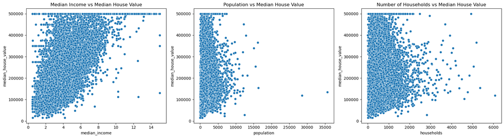

```python
import seaborn as sns
import matplotlib.pyplot as plt

# Statistics
print(data.describe())

# Scatter Plots
plt.figure(figsize=(18, 5))

# Median Income
plt.subplot(1, 3, 1)
sns.scatterplot(x='median_income', y='median_house_value', data=data)
plt.title('Median Income vs Median House Value')

# Population
plt.subplot(1, 3, 2)
sns.scatterplot(x='population', y='median_house_value', data=data)
plt.title('Population vs Median House Value')

# Number of Households
plt.subplot(1, 3, 3)
sns.scatterplot(x='households', y='median_house_value', data=data)
plt.title('Number of Households vs Median House Value')

plt.tight_layout()
plt.show()
```

1. Running Linear Regressions:

```python
from sklearn.linear_model import LinearRegression
from sklearn.metrics import mean_squared_error, mean_absolute_error

# Prepare data for models
X_income = data[['median_income']]
X_population = data[['population']]
X_households = data[['households']]
y = data['median_house_value']

# Linear Regression Models
model_income = LinearRegression().fit(X_income, y)
model_population = LinearRegression().fit(X_population, y)
model_households = LinearRegression().fit(X_households, y)

# Predictions
y_pred_income = model_income.predict(X_income)
y_pred_population = model_population.predict(X_population)
y_pred_households = model_households.predict(X_households)

# Metrics
def metrics(y_true, y_pred):
    return {
        'MSE': mean_squared_error(y_true, y_pred),
        'MAE': mean_absolute_error(y_true, y_pred)
    }

metrics_income = metrics(y, y_pred_income)
metrics_population = metrics(y, y_pred_population)
metrics_households = metrics(y, y_pred_households)

results = pd.DataFrame({
    'Model': ['Income', 'Population', 'Households'],
    'Intercept': [model_income.intercept_, model_population.intercept_, model_households.intercept_],
    'Slope': [model_income.coef_[0], model_population.coef_[0], model_households.coef_[0]],
    'MSE': [metrics_income['MSE'], metrics_population['MSE'], metrics_households['MSE']],
    'MAE': [metrics_income['MAE'], metrics_population['MAE'], metrics_households['MAE']]
})

results
```

|  | Model | Intercept | Slope | MSE | MAE |
| --- | --- | --- | --- | --- | --- |
| 0 | Income | 45085.576703 | 41793.849202 | 7.011312e+09 | 62625.933791 |
| 1 | Population | 210436.262076 | -2.511753 | 1.330741e+10 | 91153.820095 |
| 2 | Households | 196928.577162 | 19.872775 | 1.325778e+10 | 90802.743243 |

1. Plotting Results:

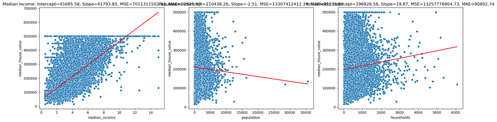

```python
plt.figure(figsize=(18, 5))

# Median Income
plt.subplot(1, 3, 1)
sns.scatterplot(x='median_income', y='median_house_value', data=data)
plt.plot(data['median_income'], y_pred_income, color='red')
plt.title(f'Median Income: Intercept={model_income.intercept_:.2f}, Slope={model_income.coef_[0]:.2f}, MSE={metrics_income["MSE"]:.2f}, MAE={metrics_income["MAE"]:.2f}')

# Population
plt.subplot(1, 3, 2)
sns.scatterplot(x='population', y='median_house_value', data=data)
plt.plot(data['population'], y_pred_population, color='red')
plt.title(f'Population: Intercept={model_population.intercept_:.2f}, Slope={model_population.coef_[0]:.2f}, MSE={metrics_population["MSE"]:.2f}, MAE={metrics_population["MAE"]:.2f}')

# Number of Households
plt.subplot(1, 3, 3)
sns.scatterplot(x='households', y='median_house_value', data=data)
plt.plot(data['households'], y_pred_households, color='red')
plt.title(f'Households: Intercept={model_households.intercept_:.2f}, Slope={model_households.coef_[0]:.2f}, MSE={metrics_households["MSE"]:.2f}, MAE={metrics_households["MAE"]:.2f}')

plt.tight_layout()
plt.show()
```

1. Summary and Conclusion:

## Summary and Conclusion

After analyzing the models, the following conclusions can be drawn:

- **Median Income Model:** This model shows a relatively strong fit with lower MSE and MAE compared to other models.
- **Population Model:** This model has a higher MSE and MAE, suggesting a weaker fit.
- **Number of Households Model:** This model also demonstrates a weaker fit compared to the Median Income model.

**Recommendation:** Based on the analysis, the model using Median Income as the predictor provides the best fit for predicting Median House Value. Further exploration and potentially including more features could improve the model performance.